# COVID-19 Report

MJF

2023-07-28

In this notebook we looked at global, UK, US, and Colorado COVID-19 cases and deaths to see if we can uncover any trends regarding the past few years. Some libraries you will need are: stringr, readr, tidyverse, and lubridate.

## Identify and import the data

Read in the data from Johns Hopkins COVID-19 cases and deaths.

```r
library(stringr)
library(readr)

# Save the links and read the csvs.
url_path = "https://raw.githubusercontent.com/CSSEGISandData/COVID-19/master/csse_covid_19_data/csse_covid_19_time_series/"
file_names = c("time_series_covid19_confirmed_global.csv", "time_series_covid19_deaths_global.csv", "time_series_covid19_confirmed_US.csv", "time_series_covid19_deaths_US.csv")
urls = str_c(url_path,file_names)
urls
```

```
## [1] "https://raw.githubusercontent.com/CSSEGISandData/COVID-19/master/csse_covid_19_data/csse_covid_19_time_series/time_series_covid19_confirmed_global.csv"
## [2] "https://raw.githubusercontent.com/CSSEGISandData/COVID-19/master/csse_covid_19_data/csse_covid_19_time_series/time_series_covid19_deaths_global.csv"
## [3] "https://raw.githubusercontent.com/CSSEGISandData/COVID-19/master/csse_covid_19_data/csse_covid_19_time_series/time_series_covid19_confirmed_US.csv"
## [4] "https://raw.githubusercontent.com/CSSEGISandData/COVID-19/master/csse_covid_19_data/csse_covid_19_time_series/time_series_covid19_deaths_US.csv"
```

```r
# Assign the data to variables
global_cases = read_csv(urls[1])
global_deaths = read_csv(urls[2])
US_cases = read_csv(urls[3])
US_deaths = read_csv(urls[4])

head(global_cases)
```

```
## # A tibble: 6 × 1,147
##   `Province/State` `Country/Region`   Lat  Long `1/22/20` `1/23/20` `1/24/20`
##   <chr>            <chr>            <dbl> <dbl>     <dbl>     <dbl>     <dbl>
## 1 <NA>             Afghanistan       33.9 67.7          0         0         0
## 2 <NA>             Albania           41.2 20.2          0         0         0
## 3 <NA>             Algeria           28.0  1.66         0         0         0
## 4 <NA>             Andorra           42.5  1.52         0         0         0
## 5 <NA>             Angola           -11.2 17.9          0         0         0
## 6 <NA>             Antarctica       -71.9 23.3          0         0         0
## # ℹ 1,140 more variables: `1/25/20` <dbl>, `1/26/20` <dbl>, `1/27/20` <dbl>,
## #   `1/28/20` <dbl>, `1/29/20` <dbl>, `1/30/20` <dbl>, `1/31/20` <dbl>,
## #   `2/1/20` <dbl>, `2/2/20` <dbl>, `2/3/20` <dbl>, `2/4/20` <dbl>,
## #   `2/5/20` <dbl>, `2/6/20` <dbl>, `2/7/20` <dbl>, `2/8/20` <dbl>,
## #   `2/9/20` <dbl>, `2/10/20` <dbl>, `2/11/20` <dbl>, `2/12/20` <dbl>,
## #   `2/13/20` <dbl>, `2/14/20` <dbl>, `2/15/20` <dbl>, `2/16/20` <dbl>,
## #   `2/17/20` <dbl>, `2/18/20` <dbl>, `2/19/20` <dbl>, `2/20/20` <dbl>, …
```

Now we can look at the tables and learn more about the data.

## Tidy and transforming the data

### Tidying global data

Learning about the global data.

```r
library(tidyverse)
library(lubridate)

# Tidy global_cases.
global_cases = global_cases %>% pivot_longer(cols = -c('Province/State', 'Country/Region', Lat, Long), names_to = "date", values_to = "cases") %>% select(-c(Lat, Long))
head(global_cases)
```

```
## # A tibble: 6 × 4
##   `Province/State` `Country/Region` date    cases
##   <chr>            <chr>            <chr>   <dbl>
## 1 <NA>             Afghanistan      1/22/20     0
## 2 <NA>             Afghanistan      1/23/20     0
## 3 <NA>             Afghanistan      1/24/20     0
## 4 <NA>             Afghanistan      1/25/20     0
## 5 <NA>             Afghanistan      1/26/20     0
## 6 <NA>             Afghanistan      1/27/20     0
```

```r
# Tidy global_deaths.
global_deaths = global_deaths %>% pivot_longer(cols = -c('Province/State', 'Country/Region', Lat, Long), names_to = "date", values_to = "deaths") %>% select(-c(Lat, Long))
head(global_deaths)
```

```
## # A tibble: 6 × 4
##   `Province/State` `Country/Region` date    deaths
##   <chr>            <chr>            <chr>    <dbl>
## 1 <NA>             Afghanistan      1/22/20      0
## 2 <NA>             Afghanistan      1/23/20      0
## 3 <NA>             Afghanistan      1/24/20      0
## 4 <NA>             Afghanistan      1/25/20      0
## 5 <NA>             Afghanistan      1/26/20      0
## 6 <NA>             Afghanistan      1/27/20      0
```

```r
# Join data.
global = global_cases %>% full_join(global_deaths) %>% rename(Country_Region = `Country/Region`, Province_State = `Province/State`) %>% mutate(date = mdy(date))
head(global)
```

```
## # A tibble: 6 × 5
##   Province_State Country_Region date       cases deaths
##   <chr>          <chr>          <date>     <dbl>  <dbl>
## 1 <NA>           Afghanistan    2020-01-22     0      0
## 2 <NA>           Afghanistan    2020-01-23     0      0
## 3 <NA>           Afghanistan    2020-01-24     0      0
## 4 <NA>           Afghanistan    2020-01-25     0      0
## 5 <NA>           Afghanistan    2020-01-26     0      0
## 6 <NA>           Afghanistan    2020-01-27     0      0
```

```r
summary(global)
```

```
##  Province_State     Country_Region          date                cases
##  Length:330327      Length:330327      Min.   :2020-01-22   Min.   :        0
##  Class :character   Class :character   1st Qu.:2020-11-02   1st Qu.:      680
##  Mode  :character   Mode  :character   Median :2021-08-15   Median :    14429
##                                        Mean   :2021-08-15   Mean   :   959384
##                                        3rd Qu.:2022-05-28   3rd Qu.:   228517
##                                        Max.   :2023-03-09   Max.   :103802702
##      deaths
##  Min.   :      0
##  1st Qu.:      3
##  Median :    150
##  Mean   :  13380
##  3rd Qu.:   3032
##  Max.   :1123836
```

```r
# Filter for cases.
global = global %>% filter(cases > 0)
summary(global)
```

```
##  Province_State     Country_Region          date                cases
##  Length:306827      Length:306827      Min.   :2020-01-22   Min.   :        1
##  Class :character   Class :character   1st Qu.:2020-12-12   1st Qu.:     1316
##  Mode  :character   Mode  :character   Median :2021-09-16   Median :    20365
##                                        Mean   :2021-09-11   Mean   :  1032863
##                                        3rd Qu.:2022-06-15   3rd Qu.:   271281
##                                        Max.   :2023-03-09   Max.   :103802702
##      deaths
##  Min.   :      0
##  1st Qu.:      7
##  Median :    214
##  Mean   :  14405
##  3rd Qu.:   3665
##  Max.   :1123836
```

```r
# Check maximum.
global %>% filter(cases > 103000000)
```

```
## # A tibble: 23 × 5
##    Province_State Country_Region date           cases  deaths
##    <chr>          <chr>          <date>         <dbl>   <dbl>
##  1 <NA>           US             2023-02-15 103023231 1115741
##  2 <NA>           US             2023-02-16 103083910 1116851
##  3 <NA>           US             2023-02-17 103131898 1117572
##  4 <NA>           US             2023-02-18 103134605 1117589
##  5 <NA>           US             2023-02-19 103136077 1117590
##  6 <NA>           US             2023-02-20 103138119 1117663
##  7 <NA>           US             2023-02-21 103198669 1118025
##  8 <NA>           US             2023-02-22 103308832 1118886
##  9 <NA>           US             2023-02-23 103365511 1119521
## 10 <NA>           US             2023-02-24 103378408 1119573
## # ℹ 13 more rows
```

We don’t need lat and long for this analysis. Also, we want to clean the data a bit when it comes to the date since each date is a column (we want it to be just 1 column for all the dates.)

### Tidying US cases.

Now we can do similar tidying with US cases.

```r
head(US_cases)
```

```
## # A tibble: 6 × 1,154
##        UID iso2  iso3  code3  FIPS Admin2  Province_State Country_Region   Lat
##      <dbl> <chr> <chr> <dbl> <dbl> <chr>   <chr>          <chr>          <dbl>
## 1 84001001 US    USA     840  1001 Autauga Alabama        US              32.5
## 2 84001003 US    USA     840  1003 Baldwin Alabama        US              30.7
## 3 84001005 US    USA     840  1005 Barbour Alabama        US              31.9
## 4 84001007 US    USA     840  1007 Bibb    Alabama        US              33.0
## 5 84001009 US    USA     840  1009 Blount  Alabama        US              34.0
## 6 84001011 US    USA     840  1011 Bullock Alabama        US              32.1
## # ℹ 1,145 more variables: Long_ <dbl>, Combined_Key <chr>, `1/22/20` <dbl>,
## #   `1/23/20` <dbl>, `1/24/20` <dbl>, `1/25/20` <dbl>, `1/26/20` <dbl>,
## #   `1/27/20` <dbl>, `1/28/20` <dbl>, `1/29/20` <dbl>, `1/30/20` <dbl>,
## #   `1/31/20` <dbl>, `2/1/20` <dbl>, `2/2/20` <dbl>, `2/3/20` <dbl>,
## #   `2/4/20` <dbl>, `2/5/20` <dbl>, `2/6/20` <dbl>, `2/7/20` <dbl>,
## #   `2/8/20` <dbl>, `2/9/20` <dbl>, `2/10/20` <dbl>, `2/11/20` <dbl>,
## #   `2/12/20` <dbl>, `2/13/20` <dbl>, `2/14/20` <dbl>, `2/15/20` <dbl>, …
```

```r
# Tidy US_cases.
US_cases = US_cases %>% pivot_longer(cols = -(UID:Combined_Key), names_to = "date", values_to = "cases") %>% select(Admin2:cases) %>% mutate(date = mdy(date)) %>% select(-c(Lat, Long_))
head(US_cases)
```

```
## # A tibble: 6 × 6
##   Admin2  Province_State Country_Region Combined_Key         date       cases
##   <chr>   <chr>          <chr>          <chr>                <date>     <dbl>
## 1 Autauga Alabama        US             Autauga, Alabama, US 2020-01-22     0
## 2 Autauga Alabama        US             Autauga, Alabama, US 2020-01-23     0
## 3 Autauga Alabama        US             Autauga, Alabama, US 2020-01-24     0
## 4 Autauga Alabama        US             Autauga, Alabama, US 2020-01-25     0
## 5 Autauga Alabama        US             Autauga, Alabama, US 2020-01-26     0
## 6 Autauga Alabama        US             Autauga, Alabama, US 2020-01-27     0
```

```r
# Tidy US_deaths.
head(US_deaths)
```

```
## # A tibble: 6 × 1,155
##        UID iso2  iso3  code3  FIPS Admin2  Province_State Country_Region   Lat
##      <dbl> <chr> <chr> <dbl> <dbl> <chr>   <chr>          <chr>          <dbl>
## 1 84001001 US    USA     840  1001 Autauga Alabama        US              32.5
## 2 84001003 US    USA     840  1003 Baldwin Alabama        US              30.7
## 3 84001005 US    USA     840  1005 Barbour Alabama        US              31.9
## 4 84001007 US    USA     840  1007 Bibb    Alabama        US              33.0
## 5 84001009 US    USA     840  1009 Blount  Alabama        US              34.0
## 6 84001011 US    USA     840  1011 Bullock Alabama        US              32.1
## # ℹ 1,146 more variables: Long_ <dbl>, Combined_Key <chr>, Population <dbl>,
## #   `1/22/20` <dbl>, `1/23/20` <dbl>, `1/24/20` <dbl>, `1/25/20` <dbl>,
## #   `1/26/20` <dbl>, `1/27/20` <dbl>, `1/28/20` <dbl>, `1/29/20` <dbl>,
## #   `1/30/20` <dbl>, `1/31/20` <dbl>, `2/1/20` <dbl>, `2/2/20` <dbl>,
## #   `2/3/20` <dbl>, `2/4/20` <dbl>, `2/5/20` <dbl>, `2/6/20` <dbl>,
## #   `2/7/20` <dbl>, `2/8/20` <dbl>, `2/9/20` <dbl>, `2/10/20` <dbl>,
## #   `2/11/20` <dbl>, `2/12/20` <dbl>, `2/13/20` <dbl>, `2/14/20` <dbl>, …
```

```r
US_deaths = US_deaths %>% pivot_longer(cols = -(UID:Population), names_to = "date", values_to = "deaths") %>% select(Admin2:deaths) %>% mutate(date = mdy(date)) %>% select(-c(Lat, Long_))
head(US_deaths)
```

```
## # A tibble: 6 × 7
##   Admin2 Province_State Country_Region Combined_Key Population date       deaths
##   <chr>  <chr>          <chr>          <chr>             <dbl> <date>      <dbl>
## 1 Autau… Alabama        US             Autauga, Al…      55869 2020-01-22      0
## 2 Autau… Alabama        US             Autauga, Al…      55869 2020-01-23      0
## 3 Autau… Alabama        US             Autauga, Al…      55869 2020-01-24      0
## 4 Autau… Alabama        US             Autauga, Al…      55869 2020-01-25      0
## 5 Autau… Alabama        US             Autauga, Al…      55869 2020-01-26      0
## 6 Autau… Alabama        US             Autauga, Al…      55869 2020-01-27      0
```

```r
# Join US cases and deaths.
US = US_cases %>% full_join(US_deaths)
```

[output not shown]

```r
head(US)
```

```
## # A tibble: 6 × 8
##   Admin2  Province_State Country_Region Combined_Key date       cases Population
##   <chr>   <chr>          <chr>          <chr>        <date>     <dbl>      <dbl>
## 1 Autauga Alabama        US             Autauga, Al… 2020-01-22     0      55869
## 2 Autauga Alabama        US             Autauga, Al… 2020-01-23     0      55869
## 3 Autauga Alabama        US             Autauga, Al… 2020-01-24     0      55869
## 4 Autauga Alabama        US             Autauga, Al… 2020-01-25     0      55869
## 5 Autauga Alabama        US             Autauga, Al… 2020-01-26     0      55869
## 6 Autauga Alabama        US             Autauga, Al… 2020-01-27     0      55869
## # ℹ 1 more variable: deaths <dbl>
```

### Adding population to global dataset

Now we need to get population for our global cases just like the US cases.

```r
# Add Combined_Key column.
global = global %>% unite("Combined_Key", c(Province_State, Country_Region), sep = ",", na.rm = TRUE, remove = FALSE)
head(global)
```

```
## # A tibble: 6 × 6
##   Combined_Key Province_State Country_Region date       cases deaths
##   <chr>        <chr>          <chr>          <date>     <dbl>  <dbl>
## 1 Afghanistan  <NA>           Afghanistan    2020-02-24     5      0
## 2 Afghanistan  <NA>           Afghanistan    2020-02-25     5      0
## 3 Afghanistan  <NA>           Afghanistan    2020-02-26     5      0
## 4 Afghanistan  <NA>           Afghanistan    2020-02-27     5      0
## 5 Afghanistan  <NA>           Afghanistan    2020-02-28     5      0
## 6 Afghanistan  <NA>           Afghanistan    2020-02-29     5      0
```

```r
# Get population info.
uid_lookup_url = "https://raw.githubusercontent.com/CSSEGISandData/COVID-19/master/csse_covid_19_data/UID_ISO_FIPS_LookUp_Table.csv"
uid = read_csv(uid_lookup_url) %>% select(-c(Lat, Long_, Combined_Key, code3, iso2, iso3, Admin2))
head(uid)
```

```
## # A tibble: 6 × 5
##     UID FIPS  Province_State Country_Region Population
##   <dbl> <chr> <chr>          <chr>               <dbl>
## 1     4 <NA>  <NA>           Afghanistan      38928341
## 2     8 <NA>  <NA>           Albania           2877800
## 3    10 <NA>  <NA>           Antarctica             NA
## 4    12 <NA>  <NA>           Algeria          43851043
## 5    20 <NA>  <NA>           Andorra             77265
## 6    24 <NA>  <NA>           Angola           32866268
```

```r
global = global %>% left_join(uid, by = c("Province_State", "Country_Region")) %>% select(-c(UID, FIPS)) %>% select(Province_State, Country_Region, date, cases, deaths, Population, Combined_Key)
head(global)
```

```
## # A tibble: 6 × 7
##   Province_State Country_Region date       cases deaths Population Combined_Key
##   <chr>          <chr>          <date>     <dbl>  <dbl>      <dbl> <chr>
## 1 <NA>           Afghanistan    2020-02-24     5      0   38928341 Afghanistan
## 2 <NA>           Afghanistan    2020-02-25     5      0   38928341 Afghanistan
## 3 <NA>           Afghanistan    2020-02-26     5      0   38928341 Afghanistan
## 4 <NA>           Afghanistan    2020-02-27     5      0   38928341 Afghanistan
## 5 <NA>           Afghanistan    2020-02-28     5      0   38928341 Afghanistan
## 6 <NA>           Afghanistan    2020-02-29     5      0   38928341 Afghanistan
```

Now that we have tidied our data and joined them, we can visualize, analyze, and model our data.

## Visualizing, analyzing, and modeling data

### Visualizing global data

We can visualize our global data.

```r
# Get sum for cases and deaths for each Country_Region.
global_by_country = global %>% group_by(Country_Region, date) %>% summarize(cases = sum(cases), deaths = sum(deaths), Population = sum(Population)) %>% mutate(deaths_per_mill = deaths *1000000 / Population) %>% select(Country_Region, date, cases, deaths, deaths_per_mill, Population) %>% ungroup()
head(global_by_country)
```

```
## # A tibble: 6 × 6
##   Country_Region date       cases deaths deaths_per_mill Population
##   <chr>          <date>     <dbl>  <dbl>           <dbl>      <dbl>
## 1 Afghanistan    2020-02-24     5      0               0   38928341
## 2 Afghanistan    2020-02-25     5      0               0   38928341
## 3 Afghanistan    2020-02-26     5      0               0   38928341
## 4 Afghanistan    2020-02-27     5      0               0   38928341
## 5 Afghanistan    2020-02-28     5      0               0   38928341
## 6 Afghanistan    2020-02-29     5      0               0   38928341
```

```r
# Get cases and deaths for Globe.
globe = global_by_country %>% group_by(date) %>% summarize(cases = sum(cases), deaths = sum(deaths), Population = sum(Population)) %>% mutate(deaths_per_mill = deaths *1000000 / Population) %>% select( date, cases, deaths, deaths_per_mill, Population) %>% ungroup()
head(globe)
```

```
## # A tibble: 6 × 5
##   date       cases deaths deaths_per_mill Population
##   <date>     <dbl>  <dbl>           <dbl>      <dbl>
## 1 2020-01-22   557     17         0.00928 1831310815
## 2 2020-01-23   657     18         0.00856 2103147721
## 3 2020-01-24   944     26         0.0119  2192446719
## 4 2020-01-25  1437     42         0.0186  2259873482
## 5 2020-01-26  2120     56         0.0246  2274621382
## 6 2020-01-27  2929     82         0.0342  2395908634
```

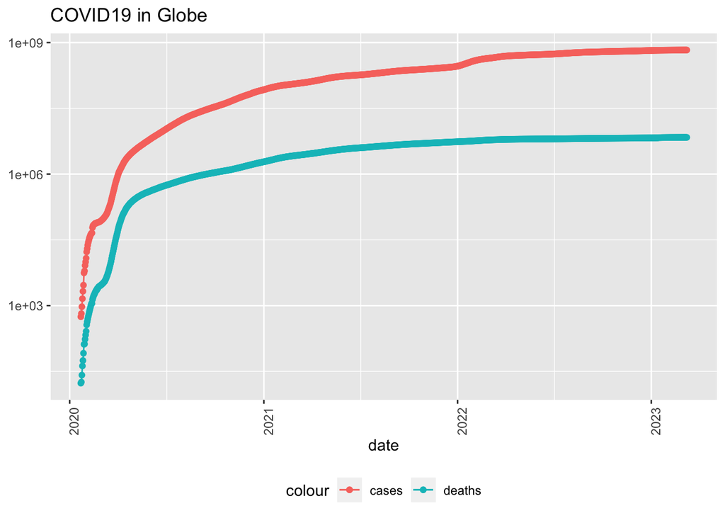

```r
# Plot global.
globe %>% filter(cases > 0) %>% ggplot(aes(x = date, y = cases)) +
  geom_line(aes(color = "cases")) +
  geom_point(aes(color = "cases")) +
  geom_line(aes(y = deaths, color = "deaths")) +
  geom_point(aes(y = deaths, color = "deaths")) +
  scale_y_log10() +
  theme(legend.position = "bottom", axis.text.x = element_text(angle = 90)) +
  labs(title = "COVID19 in Globe", y = NULL)
```

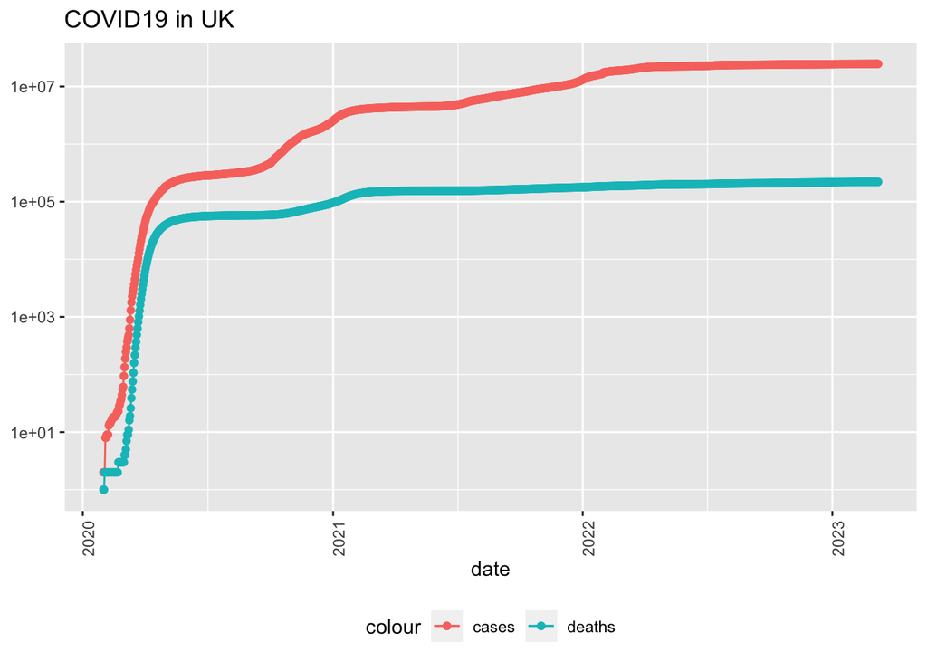

```r
# Plot a Country - United Kingdom.
UK = "United Kingdom"
global_by_country %>% filter(Country_Region == UK) %>%
  filter(cases > 0) %>%
  ggplot(aes(x = date, y = cases)) +
  geom_line(aes(color = "cases")) +
  geom_point(aes(color = "cases")) +
  geom_line(aes(y = deaths, color = "deaths")) +
  geom_point(aes(y = deaths, color = "deaths")) +
  scale_y_log10() +
  theme(legend.position = "bottom", axis.text.x = element_text(angle = 90)) +
  labs(title = "COVID19 in UK", y = NULL)
```

For the globe, it seems like after 2021 COVID19 deaths level off but cases still are rising a bit. A similar thing is seen in the UK.

### Visualizing US data

Do something similar but for US data.

```r
# Get sum for cases and deaths for each state.
US_by_state = US %>% group_by(Province_State, Country_Region, date) %>% summarize(cases = sum(cases), deaths = sum(deaths), Population = sum(Population)) %>% mutate(deaths_per_mill = deaths *1000000 / Population) %>% select(Province_State, Country_Region, date, cases, deaths, deaths_per_mill, Population) %>% ungroup()
head(US_by_state) # Alabama population is ~ 5.04 million which is close to our number (4.9 million)
```

```
## # A tibble: 6 × 7
##   Province_State Country_Region date       cases deaths deaths_per_mill
##   <chr>          <chr>          <date>     <dbl>  <dbl>           <dbl>
## 1 Alabama        US             2020-01-22     0      0               0
## 2 Alabama        US             2020-01-23     0      0               0
## 3 Alabama        US             2020-01-24     0      0               0
## 4 Alabama        US             2020-01-25     0      0               0
## 5 Alabama        US             2020-01-26     0      0               0
## 6 Alabama        US             2020-01-27     0      0               0
## # ℹ 1 more variable: Population <dbl>
```

```r
# US total for each date.
US_total = US_by_state %>% group_by(Country_Region, date) %>% summarize(cases = sum(cases), deaths = sum(deaths), Population = sum(Population)) %>% mutate(deaths_per_mill = deaths *1000000 / Population) %>% select(Country_Region, date, cases, deaths, deaths_per_mill, Population) %>% ungroup()
head(US_total)
```

```
## # A tibble: 6 × 6
##   Country_Region date       cases deaths deaths_per_mill Population
##   <chr>          <date>     <dbl>  <dbl>           <dbl>      <dbl>
## 1 US             2020-01-22     1      1         0.00300  332875137
## 2 US             2020-01-23     1      1         0.00300  332875137
## 3 US             2020-01-24     2      1         0.00300  332875137
## 4 US             2020-01-25     2      1         0.00300  332875137
## 5 US             2020-01-26     5      1         0.00300  332875137
## 6 US             2020-01-27     5      1         0.00300  332875137
```

```r
tail(US_total)
```

```
## # A tibble: 6 × 6
##   Country_Region date           cases  deaths deaths_per_mill Population
##   <chr>          <date>         <dbl>   <dbl>           <dbl>      <dbl>
## 1 US             2023-03-04 103650837 1122172           3371.  332875137
## 2 US             2023-03-05 103646975 1122134           3371.  332875137
## 3 US             2023-03-06 103655539 1122181           3371.  332875137
## 4 US             2023-03-07 103690910 1122516           3372.  332875137
## 5 US             2023-03-08 103755771 1123246           3374.  332875137
## 6 US             2023-03-09 103802702 1123836           3376.  332875137
```

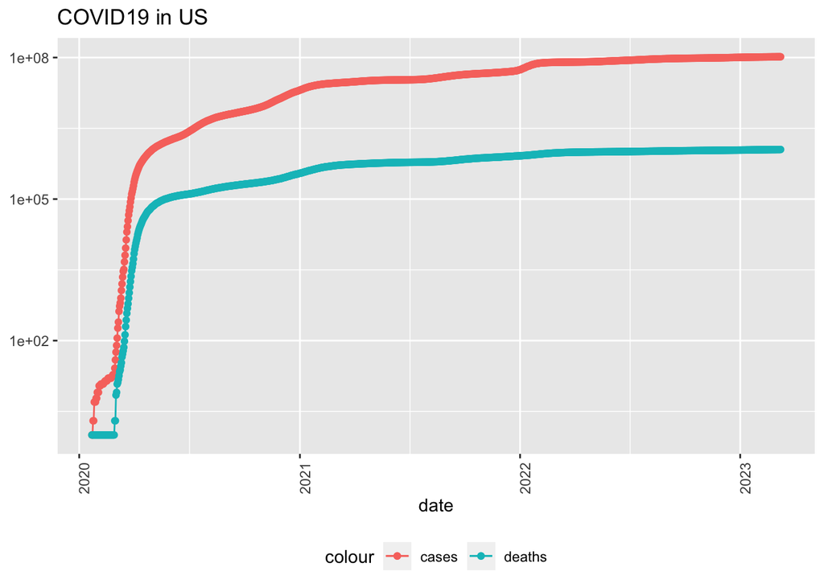

```r
view(US_by_state)

# Plot US_total.
US_total %>% filter(cases > 0) %>% ggplot(aes(x = date, y = cases)) +
  geom_line(aes(color = "cases")) +
  geom_point(aes(color = "cases")) +
  geom_line(aes(y = deaths, color = "deaths")) +
  geom_point(aes(y = deaths, color = "deaths")) +
  scale_y_log10() +
  theme(legend.position = "bottom", axis.text.x = element_text(angle = 90)) +
  labs(title = "COVID19 in US", y = NULL)
```

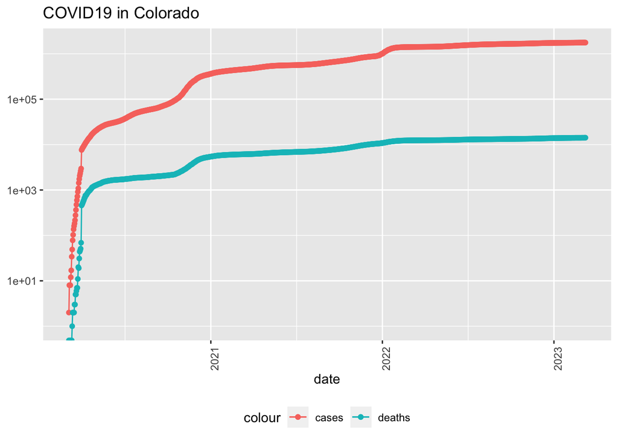

```r
# Plot Colorado.
CO = "Colorado"
US_by_state %>% filter(Province_State == CO) %>%
  filter(cases > 0) %>%
  ggplot(aes(x = date, y = cases)) +
  geom_line(aes(color = "cases")) +
  geom_point(aes(color = "cases")) +
  geom_line(aes(y = deaths, color = "deaths")) +
  geom_point(aes(y = deaths, color = "deaths")) +
  scale_y_log10() +
  theme(legend.position = "bottom", axis.text.x = element_text(angle = 90)) +
  labs(title = "COVID19 in Colorado", y = NULL)
```

For the US, it seems like after 2021 COVID19 deaths level off but cases still are rising a bit until 2022 where the cases start to level off. A similar thing is seen in the Colorado.

### Analyzing data

We want to confirm if cases have really leveled off. We can do this for the global dataset but just want to focus on the US now.

```r
# Calculate new cases and new deaths.
US_by_state = US_by_state %>% mutate(new_cases = cases - lag(cases), new_deaths = deaths - lag(deaths))
head(US_by_state)
```

```
## # A tibble: 6 × 9
##   Province_State Country_Region date       cases deaths deaths_per_mill
##   <chr>          <chr>          <date>     <dbl>  <dbl>           <dbl>
## 1 Alabama        US             2020-01-22     0      0               0
## 2 Alabama        US             2020-01-23     0      0               0
## 3 Alabama        US             2020-01-24     0      0               0
## 4 Alabama        US             2020-01-25     0      0               0
## 5 Alabama        US             2020-01-26     0      0               0
## 6 Alabama        US             2020-01-27     0      0               0
## # ℹ 3 more variables: Population <dbl>, new_cases <dbl>, new_deaths <dbl>
```

```r
tail(US_by_state)
```

```
## # A tibble: 6 × 9
##   Province_State Country_Region date        cases deaths deaths_per_mill
##   <chr>          <chr>          <date>      <dbl>  <dbl>           <dbl>
## 1 Wyoming        US             2023-03-04 185159   2002           3459.
## 2 Wyoming        US             2023-03-05 185159   2002           3459.
## 3 Wyoming        US             2023-03-06 185159   2002           3459.
## 4 Wyoming        US             2023-03-07 185385   2004           3463.
## 5 Wyoming        US             2023-03-08 185385   2004           3463.
## 6 Wyoming        US             2023-03-09 185385   2004           3463.
## # ℹ 3 more variables: Population <dbl>, new_cases <dbl>, new_deaths <dbl>
```

```r
US_total = US_total %>% mutate(new_cases = cases - lag(cases), new_deaths = deaths - lag(deaths))
head(US_total)
```

```
## # A tibble: 6 × 8
##   Country_Region date       cases deaths deaths_per_mill Population new_cases
##   <chr>          <date>     <dbl>  <dbl>           <dbl>      <dbl>     <dbl>
## 1 US             2020-01-22     1      1         0.00300  332875137        NA
## 2 US             2020-01-23     1      1         0.00300  332875137         0
## 3 US             2020-01-24     2      1         0.00300  332875137         1
## 4 US             2020-01-25     2      1         0.00300  332875137         0
## 5 US             2020-01-26     5      1         0.00300  332875137         3
## 6 US             2020-01-27     5      1         0.00300  332875137         0
## # ℹ 1 more variable: new_deaths <dbl>
```

```r
tail(US_total)
```

```
## # A tibble: 6 × 8
##   Country_Region date          cases deaths deaths_per_mill Population new_cases
##   <chr>          <date>        <dbl>  <dbl>           <dbl>      <dbl>     <dbl>
## 1 US             2023-03-04   1.04e8 1.12e6           3371.  332875137      2147
## 2 US             2023-03-05   1.04e8 1.12e6           3371.  332875137     -3862
## 3 US             2023-03-06   1.04e8 1.12e6           3371.  332875137      8564
## 4 US             2023-03-07   1.04e8 1.12e6           3372.  332875137     35371
## 5 US             2023-03-08   1.04e8 1.12e6           3374.  332875137     64861
## 6 US             2023-03-09   1.04e8 1.12e6           3376.  332875137     46931
## # ℹ 1 more variable: new_deaths <dbl>
```

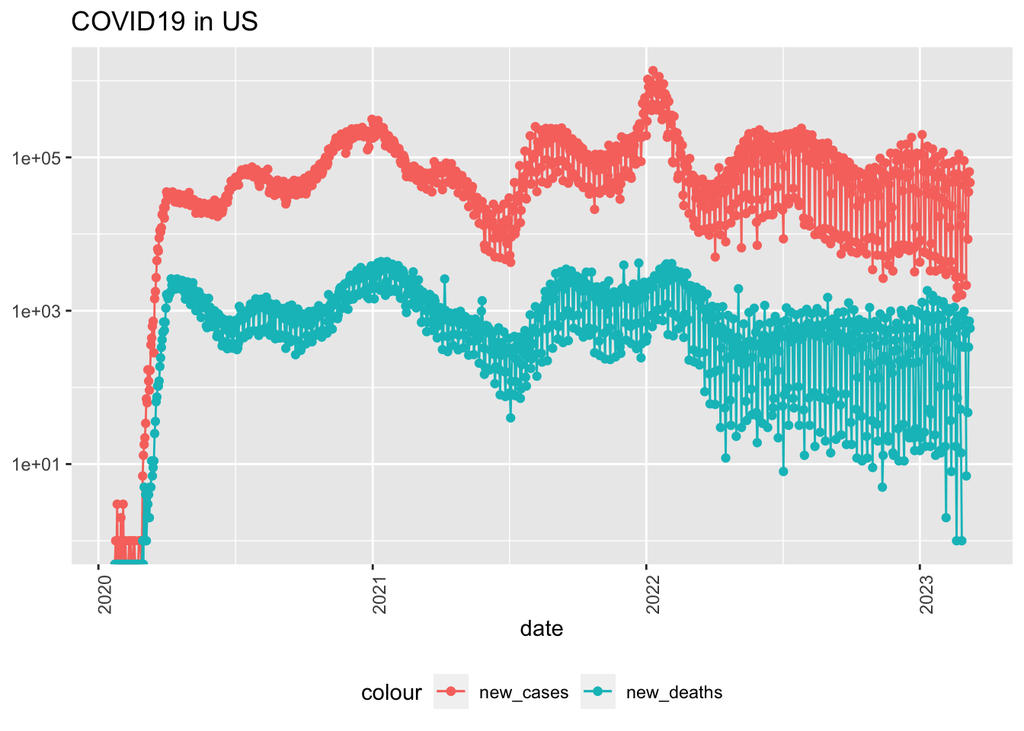

```r
# Plot new data for US.
US_total %>% ggplot(aes(x = date, y = new_cases)) +
  geom_line(aes(color = "new_cases")) +
  geom_point(aes(color = "new_cases")) +
  geom_line(aes(y = new_deaths, color = "new_deaths")) +
  geom_point(aes(y = new_deaths, color = "new_deaths")) +
  scale_y_log10() +
  theme(legend.position = "bottom", axis.text.x = element_text(angle = 90)) +
  labs(title = "COVID19 in US", y = NULL)
```

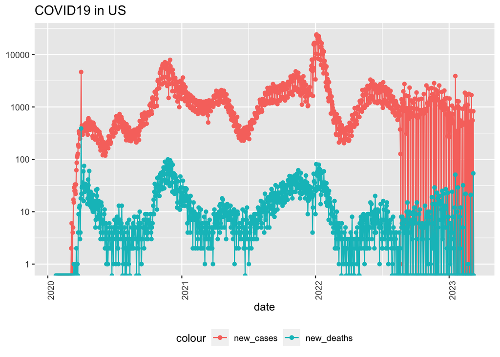

```r
# Plot new data for CO
CO = "Colorado"
US_by_state %>% filter(Province_State == CO) %>%
  ggplot(aes(x = date, y = new_cases)) +
  geom_line(aes(color = "new_cases")) +
  geom_point(aes(color = "new_cases")) +
  geom_line(aes(y = new_deaths, color = "new_deaths")) +
  geom_point(aes(y = new_deaths, color = "new_deaths")) +
  scale_y_log10() +
  theme(legend.position = "bottom", axis.text.x = element_text(angle = 90)) +
  labs(title = "COVID19 in US", y = NULL)
```

For the US, we can see there has been these waves of cases and deaths. The cases seem to level off or even drop and then there will be a spike and a leveling off or drop again. For Colorado, we see these waves too Also, we see that starting in mid 2022, the new_cases and new_deaths mostly drop to 0.

We also might want to look at the US state totals and see cases and deaths per thousand.

```r
# Get state totals.
US_state_totals = US_by_state %>% group_by(Province_State) %>% summarize(deaths = max(deaths), cases = max(cases), population = max(Population), cases_per_thou = 1000* cases / population, deaths_per_thou = 1000* deaths / population) %>% filter(cases > 0, deaths > 0)
head(US_state_totals)
```

```
## # A tibble: 6 × 6
##   Province_State deaths    cases population cases_per_thou deaths_per_thou
##   <chr>           <dbl>    <dbl>      <dbl>          <dbl>           <dbl>
## 1 Alabama         21032  1644533    4903185           335.           4.29
## 2 Alaska           1486   307655     740995           415.           2.01
## 3 American Samoa     34     8320      55641           150.           0.611
## 4 Arizona         33102  2443514    7278717           336.           4.55
## 5 Arkansas        13020  1006883    3017804           334.           4.31
## 6 California     101159 12129699   39512223           307.           2.56
```

```r
# States with least deaths per thousand.
US_state_totals %>% slice_min(deaths_per_thou, n = 10)
```

```
## # A tibble: 10 × 6
##    Province_State        deaths  cases population cases_per_thou deaths_per_thou
##    <chr>                  <dbl>  <dbl>      <dbl>          <dbl>           <dbl>
##  1 American Samoa            34 8.32e3      55641           150.           0.611
##  2 Northern Mariana Isl…     41 1.37e4      55144           248.           0.744
##  3 Virgin Islands           130 2.48e4     107268           231.           1.21
##  4 Hawaii                  1841 3.81e5    1415872           269.           1.30
##  5 Vermont                  929 1.53e5     623989           245.           1.49
##  6 Puerto Rico             5823 1.10e6    3754939           293.           1.55
##  7 Utah                    5298 1.09e6    3205958           340.           1.65
##  8 Alaska                  1486 3.08e5     740995           415.           2.01
##  9 District of Columbia    1432 1.78e5     705749           252.           2.03
## 10 Washington             15683 1.93e6    7614893           253.           2.06
```

```r
# States with most deaths per thousand.
US_state_totals %>% slice_max(deaths_per_thou, n = 10)
```

```
## # A tibble: 10 × 6
##    Province_State deaths   cases population cases_per_thou deaths_per_thou
##    <chr>           <dbl>   <dbl>      <dbl>          <dbl>           <dbl>
##  1 Grand Princess      3     103          0           Inf           Inf
##  2 Arizona         33102 2443514    7278717           336.            4.55
##  3 Oklahoma        17972 1290929    3956971           326.            4.54
##  4 Mississippi     13370  990756    2976149           333.            4.49
##  5 West Virginia    7960  642760    1792147           359.            4.44
##  6 New Mexico       9061  670929    2096829           320.            4.32
##  7 Arkansas        13020 1006883    3017804           334.            4.31
##  8 Alabama         21032 1644533    4903185           335.            4.29
##  9 Tennessee       29263 2515130    6829174           368.            4.28
## 10 Michigan        42205 3064125    9986857           307.            4.23
```

As for the states with the least deaths, we can see that some of the smaller population areas (islands) had less deaths per thousand. For the states with the most deaths per thousand, we can obviously see our data for Grand Princess is not ideal. Since we are missing information such as population, we get inf for our cases and deaths per thousand. We might want to remove Grand Princess from the data before doing any modeling since there are infs.

### Modeling

We can also try to model our deaths per thousand using our cases per thousand.

```r
# Remove data which has infs.
US_state_totals = US_state_totals %>% filter(Province_State != "Grand Princess")

# Create model.
lm_thous = lm(deaths_per_thou ~ cases_per_thou,data = US_state_totals)
summary(lm_thous)
```

```
##
## Call:
## lm(formula = deaths_per_thou ~ cases_per_thou, data = US_state_totals)
##
## Residuals:
##     Min      1Q  Median      3Q     Max
## -2.3352 -0.5978  0.1491  0.6535  1.2086
##
## Coefficients:
##                Estimate Std. Error t value Pr(>|t|)
## (Intercept)    -0.36167    0.72480  -0.499     0.62
## cases_per_thou  0.01133    0.00232   4.881 9.76e-06 ***
## ---
## Signif. codes:  0 '***' 0.001 '**' 0.01 '*' 0.05 '.' 0.1 ' ' 1
##
## Residual standard error: 0.8615 on 54 degrees of freedom
## Multiple R-squared:  0.3061, Adjusted R-squared:  0.2933
## F-statistic: 23.82 on 1 and 54 DF,  p-value: 9.763e-06
```

```r
# Create prediction.
US_state_totals = US_state_totals %>% mutate(pred = predict(lm_thous))
head(US_state_totals)
```

```
## # A tibble: 6 × 7
##   Province_State deaths    cases population cases_per_thou deaths_per_thou  pred
##   <chr>           <dbl>    <dbl>      <dbl>          <dbl>           <dbl> <dbl>
## 1 Alabama         21032  1644533    4903185           335.           4.29   3.44
## 2 Alaska           1486   307655     740995           415.           2.01   4.34
## 3 American Samoa     34     8320      55641           150.           0.611  1.33
## 4 Arizona         33102  2443514    7278717           336.           4.55   3.44
## 5 Arkansas        13020  1006883    3017804           334.           4.31   3.42
## 6 California     101159 12129699   39512223           307.           2.56   3.12
```

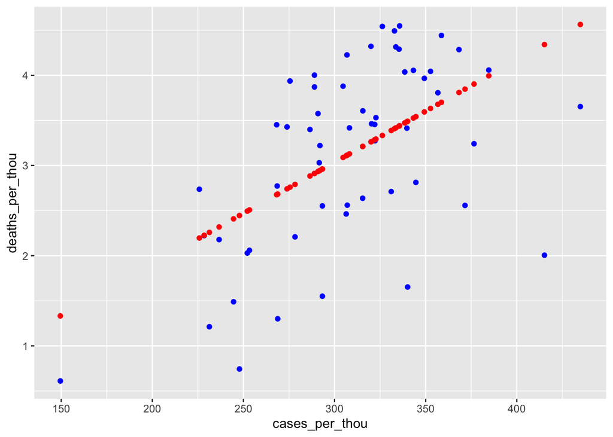

```r
# Plot predictions.
US_state_totals %>% ggplot() +
  geom_point(aes(x = cases_per_thou, y = deaths_per_thou), color = "blue") +
  geom_point(aes(x = cases_per_thou, y = pred), color = "red")
```

Our linear model is statistically significant. However, when looking at the plot, we can see the actual points (blue) are very spread out. We might want to investigate more on why some places have more or less deaths for a certain number of cases. We also might want to consider other predictors to make the prediction of deaths per thousand even better.

## Bias

Our data and analysis is not without bias. First, we might want to consider the bias of the source. The JHU data set might not be a full representation of the COVID-19 pandemic and we might need to add additional data sets in order to get closer to a better representation. Also, the data might be inflated or deflated where some cases/deaths were reported or not reported. Additionally, there might have been some underlying personal bias but steps such as looking at the data in multiple ways can help mitigate that personal bias.